# Machine Learning con R y mlr3

Joaquín Amat Rodrigo

Abril, 2020

Más sobre ciencia de datos en [**cienciadedatos.net**](https://cienciadedatos.net)

- [**tidymodels**](https://www.cienciadedatos.net/documentos/59_machine_learning_con_r_y_tidymodels)
- [**caret**](https://www.cienciadedatos.net/documentos/41_machine_learning_con_r_y_caret)
- [**H2O**](https://www.cienciadedatos.net/documentos/44_machine_learning_con_h2o_y_r)

# Introducción

Durante los últimos años, el interés y la aplicación de *machine learning* ha experimentado tal expansión, que se ha convertido en una disciplina aplicada en prácticamente todos los ámbitos de investigación académica e industrial. El creciente número de personas dedicadas a esta disciplina ha dado como resultado todo un repertorio de herramientas con las que acceder a métodos predictivos potentes. El lenguaje de programación **R** es un ejemplo de ello.

El término *machine learning* engloba al conjunto de algoritmos que permiten identificar patrones presentes en los datos y crear con ellos estructuras (modelos) que los representan. Una vez que los modelos han sido generados, se pueden emplear para predecir información sobre hechos o eventos que todavía no se han observado. Es importante recordar que, los sistemas de *machine learning*, solo son capaces de memorizar patrones que estén presentes en los datos con los que se entrenan, por lo tanto, solo pueden reconocer lo que han visto antes. Al emplear sistemas entrenados con datos pasados para predecir futuros se está asumiendo que, en el futuro, el comportamiento será el mismo, cosa que no siempre ocurre.

Aunque con frecuencia, términos como *machine learning*, *data mining*, inteligencia artificial, *data science*… son utilizados como sinónimos, es importante destacar que los métodos de *machine learning* son solo una parte de las muchas estrategias que se necesita combinar para extraer, entender y dar valor a los datos. El siguiente documento pretende ser un ejemplo del tipo de problema al que se suele enfrentar un analista: partiendo de un conjunto de datos más o menos procesado (la preparación de los datos es una etapa clave que precede al *machine learning*), se desea crear un modelo que permita predecir con éxito el comportamiento o valor que toman nuevas observaciones.

**Etapas de un problema de *machine learning***

- Definir el problema: ¿Qué se pretende predecir? ¿De qué datos se dispone? o ¿Qué datos es necesario conseguir?
- Explorar y entender los datos que se van a emplear para crear el modelo.
- Métrica de éxito: definir una forma apropiada de cuantificar cómo de buenos son los resultados obtenidos.
- Preparar la estrategia para evaluar el modelo: separar las observaciones en un conjunto de entrenamiento, un conjunto de validación (o validación cruzada) y un conjunto de test. Es muy importante asegurar que ninguna información del conjunto de test participa en el proceso de entrenamiento del modelo.
- Preprocesar los datos: aplicar las transformaciones necesarias para que los datos puedan ser interpretados por el algoritmo de *machine learning* seleccionado.
- Ajustar un primer modelo capaz de superar unos resultados mínimos. Por ejemplo, en problemas de clasificación, el mínimo a superar es el porcentaje de la clase mayoritaria (la moda).
- Gradualmente, mejorar el modelo incorporando-creando nuevas variables u optimizando los hiperparámetros.
- Evaluar la capacidad del modelo final con el conjunto de test para tener una estimación de la capacidad que tiene el modelo cuando predice nuevas observaciones.
- Entrenar el modelo final con todos los datos disponibles.

> A diferencia de otros [documentos](https://www.cienciadedatos.net/), este pretende ser un ejemplo práctico con menos desarrollo teórico. El lector podrá darse cuenta de lo sencillo que es aplicar un gran abanico de métodos predictivos con **R** y sus librerías. Sin embargo, es crucial que cualquier analista entienda los fundamentos teóricos en los que se basa cada uno de ellos para que un proyecto de este tipo tenga éxito. Aunque aquí solo se describan brevemente, estarán acompañados de links donde encontrar información detallada.

# mlr3

**R** es uno de los lenguajes de programación que domina dentro del ámbito de la estadística, *data mining* y *machine learning*. Al tratarse de un software libre, innumerables usuarios han podido implementar sus algoritmos, dando lugar a un número muy elevado de paquetes/librerías donde encontrar prácticamente todas las técnicas de *machine learning* existentes. Sin embargo, esto tiene un lado negativo, cada paquete tiene una sintaxis, estructura e implementación propia, lo que dificulta su aprendizaje. [**mlr3**](https://github.com/mlr-org/mlr3), es una interfaz que unifica bajo un único marco cientos de funciones de distintos paquetes, facilitando en gran medida todas las etapas de preprocesado, entrenamiento, optimización y validación de modelos predictivos. Los paquetes principales que forman parte del ecosistema `mlr3` son:

- [mlr3](https://mlr3.mlr-org.com): paquete *core* con las funcionalidades principales para crear los objetos necesarios para el ecosistema `mlr3`.
- [mlr3filters](https://mlr3filters.mlr-org.com): para la selección de predictores.
- [mlr3learners](https://mlr3learners.mlr-org.com): para la definición de modelos.
- paradox: para crear y manejar el valor de los hiperparámetros de los modelos.
- [mlr3tuning](https://mlr3tuning.mlr-org.com): para hacer *tuning* de los modelos.
- [mlr3viz](https://mlr3viz.mlr-org.com): para visualizar objetos `mlr3`.
- [mlr3pipelines](https://mlr3pipelines.mlr-org.com):para combinar todos los pasos del preprocesado y modelado en un único objeto.

> El paquete **mlr3** ofrece tal cantidad de posibilidades que, difícilmente, pueden ser mostradas con un único ejemplo. En este documento, se emplean solo algunas de sus funcionalidades. Si en algún caso se requiere una explicación detallada, para que no interfiera con la narrativa del análisis, se añadirá un anexo. Aun así, para conocer bien todas las funcionalidades de **mlr3** se recomienda leer su documentación.

> Aunque estos son los paquetes principales, al ser un proyecto reciente, se están madurando y creando otros con el objetivo de enriquecer el ecosistema. Esto significa que probablemente sufrirán modificaciones y que se añadirán nuevas funcionalidades (importante si se está considerando poner en producción el modelo).

> Este documento está reproducido también con [**tidymodels**](https://www.cienciadedatos.net/documentos/59_machine_learning_con_r_y_tidymodels), otro ecosistema de *machine learning* con una filosofía similar a **mlr3**. Otros proyectos similares son [**caret**](https://www.cienciadedatos.net/documentos/41_machine_learning_con_r_y_caret) y [**H2O**](https://www.cienciadedatos.net/documentos/44_machine_learning_con_h2o_y_r). Una de las características que diferencia **mlr3** del resto es que emplea programación orientada a objetos mediante el uso de la clase [R6](https://r6.r-lib.org/).

```r
# Instalación de los paquetes que unifica mlr3. Esta instalación puede tardar.
# Solo es necesario ejecutarla si no se dispone de los paquetes.
# install.packages("mlr3verse")
```

```r
library(mlr3verse)
```

Otros paquete utilizados en este documento son:

```r
library(tidyverse)
library(skimr)
library(DataExplorer)
library(ggpubr)
library(univariateML)
library(GGally)
library(mosaicData)
```

# Datos

El set de datos `SaratogaHouses` del paquete `mosaicData` contiene información sobre la precio de 1728 viviendas situadas en Saratoga County, New York, USA en el año 2006. Además del precio, incluye 15 variables adicionales:

- `price`: precio de la vivienda.
- `lotSize`: metros cuadrados de la vivienda.
- `age`: antigüedad de la vivienda.
- `landValue`: valor del terreno.
- `livingArea`: metros cuadrados habitables.
- `pctCollege`: porcentaje del vecindario con título universitario.
- `bedrooms`: número de dormitorios.
- `firplaces`: número de chimeneas.
- `bathrooms`: número de cuartos de baño (el valor 0.5 hace referencia a cuartos de baño sin ducha).
- `rooms`: número de habitaciones.
- `heating`: tipo de calefacción.
- `fuel`: tipo de alimentación de la calefacción (gas, electricidad o diesel).
- `sewer`: tipo de desagüe.
- `waterfront`: si la vivienda tiene vistas al lago.
- `newConstruction`: si la vivienda es de nueva construcción.
- `centralAir`: si la vivienda tiene aire acondicionado.

El objetivo es obtener un modelo capaz de predecir el precio del alquiler.

```r
data("SaratogaHouses", package = "mosaicData")
datos <- SaratogaHouses

# Se renombran las columnas para que sean más descriptivas
colnames(datos) <- c("precio", "metros_totales", "antiguedad", "precio_terreno",
                     "metros_habitables", "universitarios",
                     "dormitorios", "chimenea", "banyos", "habitaciones",
                     "calefaccion", "consumo_calefacion", "desague",
                     "vistas_lago","nueva_construccion", "aire_acondicionado")
```

# Análisis exploratorio

Antes de entrenar un modelo predictivo, o incluso antes de realizar cualquier cálculo con un nuevo conjunto de datos, es muy importante realizar una exploración descriptiva de los mismos. Este proceso permite entender mejor qué información contiene cada variable, así como detectar posibles errores. Algunos ejemplos frecuentes son:

- Que una columna se haya almacenado con el tipo incorrecto: una variable numérica está siendo reconocida como texto o viceversa.
- Que una variable contenga valores que no tienen sentido: por ejemplo, para indicar que no se dispone del precio de una vivienda se introduce el valor 0 o un espacio en blanco.
- Que en una variable de tipo numérico se haya introducido una palabra en lugar de un número.

Además, este análisis inicial puede dar pistas sobre qué variables son adecuadas como predictores en un modelo (más sobre esto en los siguientes apartados).

Los paquetes [`skimr`](https://docs.ropensci.org/skimr/), [`DataExplorer`](https://boxuancui.github.io/DataExplorer/) y [`GGally`](http://ggobi.github.io/ggally/) facilitan mucho esta tarea gracias a sus funciones preconfiguradas.

**Tabla resumen**

```r
skim(datos)
```

Data summary

| Name | datos |
| --- | --- |
| Number of rows | 1728 |
| Number of columns | 16 |
| _______________________ |  |
| Column type frequency: |  |
| factor | 6 |
| numeric | 10 |
| ________________________ |  |
| Group variables | None |

**Variable type: factor**

| skim_variable | n_missing | complete_rate | ordered | n_unique | top_counts |
| --- | --- | --- | --- | --- | --- |
| calefaccion | 0 | 1 | FALSE | 3 | hot: 1121, ele: 305, hot: 302 |
| consumo_calefacion | 0 | 1 | FALSE | 3 | gas: 1197, ele: 315, oil: 216 |
| desague | 0 | 1 | FALSE | 3 | pub: 1213, sep: 503, non: 12 |
| vistas_lago | 0 | 1 | FALSE | 2 | No: 1713, Yes: 15 |
| nueva_construccion | 0 | 1 | FALSE | 2 | No: 1647, Yes: 81 |
| aire_acondicionado | 0 | 1 | FALSE | 2 | No: 1093, Yes: 635 |

**Variable type: numeric**

| skim_variable | n_missing | complete_rate | mean | sd | p0 | p25 | p50 | p75 | p100 | hist |
| --- | --- | --- | --- | --- | --- | --- | --- | --- | --- | --- |
| precio | 0 | 1 | 211966.71 | 98441.39 | 5000 | 1.45e+05 | 189900.00 | 259000.00 | 775000.0 | ▅▇▂▁▁ |
| metros_totales | 0 | 1 | 0.50 | 0.70 | 0 | 1.70e-01 | 0.37 | 0.54 | 12.2 | ▇▁▁▁▁ |
| antiguedad | 0 | 1 | 27.92 | 29.21 | 0 | 1.30e+01 | 19.00 | 34.00 | 225.0 | ▇▁▁▁▁ |
| precio_terreno | 0 | 1 | 34557.19 | 35021.17 | 200 | 1.51e+04 | 25000.00 | 40200.00 | 412600.0 | ▇▁▁▁▁ |
| metros_habitables | 0 | 1 | 1754.98 | 619.94 | 616 | 1.30e+03 | 1634.50 | 2137.75 | 5228.0 | ▇▇▂▁▁ |
| universitarios | 0 | 1 | 55.57 | 10.33 | 20 | 5.20e+01 | 57.00 | 64.00 | 82.0 | ▁▃▆▇▁ |
| dormitorios | 0 | 1 | 3.15 | 0.82 | 1 | 3.00e+00 | 3.00 | 4.00 | 7.0 | ▃▇▅▁▁ |
| chimenea | 0 | 1 | 0.60 | 0.56 | 0 | 0.00e+00 | 1.00 | 1.00 | 4.0 | ▆▇▁▁▁ |
| banyos | 0 | 1 | 1.90 | 0.66 | 0 | 1.50e+00 | 2.00 | 2.50 | 4.5 | ▁▇▇▁▁ |
| habitaciones | 0 | 1 | 7.04 | 2.32 | 2 | 5.00e+00 | 7.00 | 8.25 | 12.0 | ▃▇▇▅▂ |

```r
head(datos, 3)
```

|  | precio | metros_totales | antiguedad | precio_terreno | metros_habitables | universitarios | dormitorios | chimenea | banyos | habitaciones | calefaccion | consumo_calefacion | desague | vistas_lago | nueva_construccion | aire_acondicionado |
| --- | --- | --- | --- | --- | --- | --- | --- | --- | --- | --- | --- | --- | --- | --- | --- | --- |
| 1 | 132500 | 0.09 | 42 | 50000 | 906 | 35 | 2 | 1 | 1.0 | 5 | electric | electric | septic | No | No | No |
| 2 | 181115 | 0.92 | 0 | 22300 | 1953 | 51 | 3 | 0 | 2.5 | 6 | hot water/steam | gas | septic | No | No | No |
| 3 | 109000 | 0.19 | 133 | 7300 | 1944 | 51 | 4 | 1 | 1.0 | 8 | hot water/steam | gas | public/commercial | No | No | No |

Todas las columnas tienen el tipo adecuado.

## Número de observaciones y valores ausentes

Junto con el estudio del tipo de variables, es básico conocer el número de observaciones disponibles y si todas ellas están completas. Los valores ausentes son muy importantes a la hora de crear modelos, algunos algoritmos no aceptan observaciones incompletas o bien se ven muy influenciados por ellas. Aunque la imputación de valores ausentes es parte del preprocesado y, por lo tanto, debe de aprenderse únicamente con los datos de entrenamiento, su identificación se tiene que realizar antes de separar los datos para asegurar que se establecen todas las estrategias de imputación necesarias

```r
# Número de datos ausentes por variable
datos %>% map_dbl(.f = function(x){sum(is.na(x))})
```

```
##             precio     metros_totales         antiguedad     precio_terreno
##                  0                  0                  0                  0
##  metros_habitables     universitarios        dormitorios           chimenea
##                  0                  0                  0                  0
##             banyos       habitaciones        calefaccion consumo_calefacion
##                  0                  0                  0                  0
##            desague        vistas_lago nueva_construccion aire_acondicionado
##                  0                  0                  0                  0
```

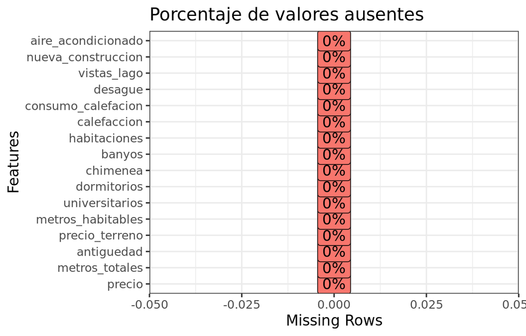

```r
plot_missing(
  data    = datos,
  title   = "Porcentaje de valores ausentes",
  ggtheme = theme_bw(),
  theme_config = list(legend.position = "none")
)
```

## Variable respuesta

Cuando se crea un modelo, es muy importante estudiar la distribución de la variable respuesta, ya que, a fin de cuentas, es lo que interesa predecir. La variable `precio` tiene una distribución asimétrica con una cola positiva debido a que, unas pocas viviendas, tienen un precio muy superior a la media. Este tipo de distribución suele visualizarse mejor tras aplicar el logarítmica o la raíz cuadrada.

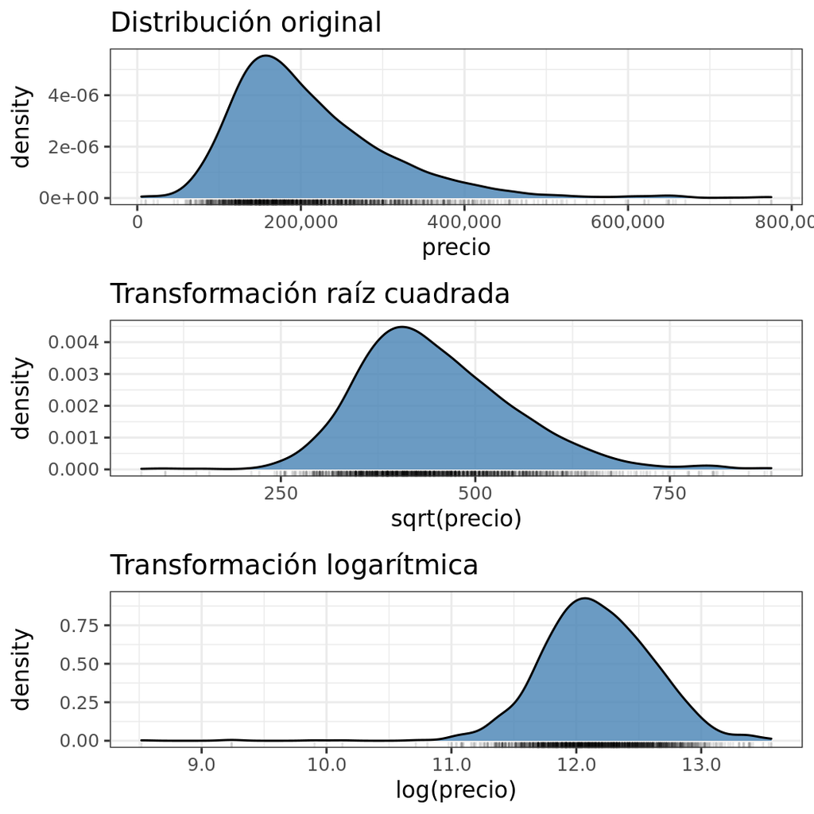

```r
p1 <- ggplot(data = datos, aes(x = precio)) +
      geom_density(fill = "steelblue", alpha = 0.8) +
      geom_rug(alpha = 0.1) +
      scale_x_continuous(labels = scales::comma) +
      labs(title = "Distribución original") +
      theme_bw()

p2 <- ggplot(data = datos, aes(x = sqrt(precio))) +
      geom_density(fill = "steelblue", alpha = 0.8) +
      geom_rug(alpha = 0.1) +
      scale_x_continuous(labels = scales::comma) +
      labs(title = "Transformación raíz cuadrada") +
      theme_bw()

p3 <- ggplot(data = datos, aes(x = log(precio))) +
      geom_density(fill = "steelblue", alpha = 0.8) +
      geom_rug(alpha = 0.1) +
      scale_x_continuous(labels = scales::comma) +
      labs(title = "Transformación logarítmica") +
      theme_bw()

ggarrange(p1, p2, p3, ncol = 1, align = "v")
```

```r
# Tabla de estadísticos principales
summary(datos$precio)
```

```
##    Min. 1st Qu.  Median    Mean 3rd Qu.    Max.
##    5000  145000  189900  211967  259000  775000
```

Algunos modelos de *machine learning* y aprendizaje estadístico requieren que la variable respuesta se distribuya de una forma determinada. Por ejemplo, para los modelos de regresión lineal (*LM*), la distribución tiene que ser de tipo normal. Para los modelos lineales generalizados (*GLM*), la distribución tiene que ser de la [familia exponencial](https://en.wikipedia.org/wiki/Exponential_family).

Existen varios paquetes en **R** que permiten identificar a qué distribución se ajustan mejor los datos, uno de ellos es `univariateML`. Para conocer más sobre cómo identificar distribuciones consultar [Ajuste de distribuciones con R](https://www.cienciadedatos.net/documentos/55_ajuste_distribuciones_con_r.html).

```r
# Se comparan únicamente las distribuciones con un dominio [0, +inf)
# Cuanto menor el valor AIC mejor el ajuste
comparacion_aic <- AIC(
                    mlbetapr(datos$precio),
                    mlexp(datos$precio),
                    mlinvgamma(datos$precio),
                    mlgamma(datos$precio),
                    mllnorm(datos$precio),
                    mlrayleigh(datos$precio),
                    mlinvgauss(datos$precio),
                    mlweibull(datos$precio),
                    mlinvweibull(datos$precio),
                    mllgamma(datos$precio)
                   )
comparacion_aic %>% rownames_to_column(var = "distribucion") %>% arrange(AIC)
```

| distribucion | df | AIC |
| --- | --- | --- |
| mlgamma(datos$precio) | 2 | 44196.85 |
| mllnorm(datos$precio) | 2 | 44214.14 |
| mlinvgauss(datos$precio) | 2 | 44409.24 |
| mlweibull(datos$precio) | 2 | 44417.64 |
| mlrayleigh(datos$precio) | 1 | 44461.57 |
| mlbetapr(datos$precio) | 2 | 44662.15 |
| mlinvgamma(datos$precio) | 2 | 44662.19 |
| mlinvweibull(datos$precio) | 2 | 45410.38 |
| mlexp(datos$precio) | 1 | 45843.02 |
| mllgamma(datos$precio) | 2 | Inf |

## Variables continuas

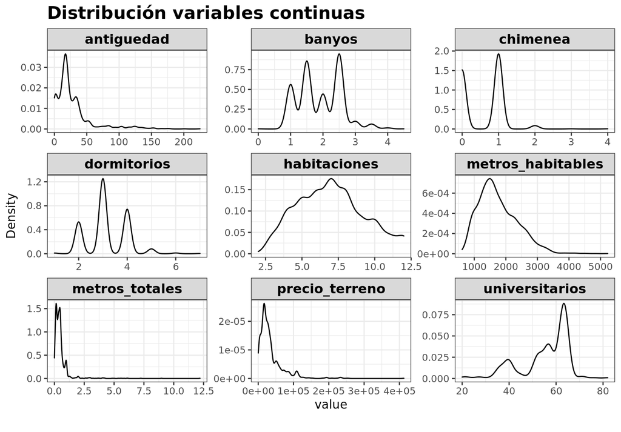

```r
plot_density(
  data    = datos %>% select(-precio),
  ncol    = 3,
  title   = "Distribución variables continuas",
  ggtheme = theme_bw(),
  theme_config = list(
                  plot.title = element_text(size = 16, face = "bold"),
                  strip.text = element_text(colour = "black", size = 12, face = 2)
                 )
  )
```

La variable `chimenea`, aunque es de tipo numérico, apenas toma unos pocos valores y la gran mayoría de observaciones pertenecen a solo dos de ellos. En casos como este, suele ser conveniente tratar la variable como cualitativa.

```r
# Valores observados de chimenea.
table(datos$chimenea)
```

```
##
##   0   1   2   3   4
## 740 942  42   2   2
```

```r
# Se convierte la variable chimenea a factor.
datos <- datos %>%
         mutate(chimenea = as.factor(chimenea))
```

Como el objetivo del estudio es predecir el precio de las viviendas, el análisis de cada variable se hace también en relación a la variable respuesta `precio`. Analizando los datos de esta forma, se pueden empezar a extraer ideas sobre qué variables están más relacionadas con el precio y de qué forma. Las variables `antiguedad`, `metros_totales` y `precio_terreno` se convierten a escala logarítmica para mejorar su representación gráfica.

```r
datos <- datos %>%
         mutate(
           # Se le añade +0.1 a la antigüedad para que cuando la antigüedad es
           # 0 no de -Inf
           log_antiguedad     = log10(antiguedad + 0.1),
           log_metros_totales = log10(metros_totales),
           log_precio_terreno = log10(precio_terreno)
         )
```

```r
custom_corr_plot <- function(variable1, variable2, df, alpha=0.3){
  p <- df %>%
       mutate(
         # Truco para que se ponga el título estilo facet
        title = paste(toupper(variable2), "vs", toupper(variable1))
       ) %>%
       ggplot(aes(x = !!sym(variable1), y = !!sym(variable2))) +
       geom_point(alpha = alpha) +
       # Tendencia no lineal
       geom_smooth(se = FALSE, method = "gam", formula =  y ~ splines::bs(x, 3)) +
       # Tendencia lineal
       geom_smooth(se = FALSE, method = "lm", color = "firebrick") +
       facet_grid(. ~ title) +
       theme_bw() +
       theme(strip.text = element_text(colour = "black", size = 8, face = 2),
             axis.title = element_blank())
  return(p)
}
```

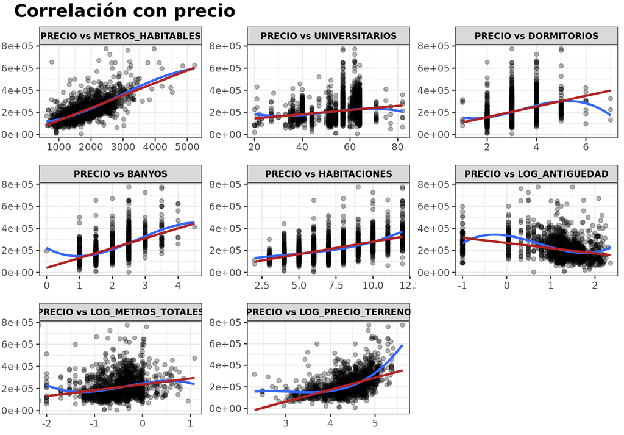

```r
variables_continuas <- c("metros_habitables", "universitarios", "dormitorios",
                         "banyos", "habitaciones", "log_antiguedad", "log_metros_totales",
                         "log_precio_terreno")

plots <- map(
            .x = variables_continuas,
            .f = custom_corr_plot,
            variable2 = "precio",
            df = datos
         )

ggarrange(plotlist = plots, ncol = 3, nrow = 3) %>%
  annotate_figure(
    top = text_grob("Correlación con precio", face = "bold", size = 16,
                    x = 0.20)
  )
```

```r
datos <- datos %>%
         select(-c(log_antiguedad, log_metros_totales, log_precio_terreno))
```

## Correlación variables continuas

Algunos modelos (*LM*, *GLM*, …) se ven perjudicados si incorporan predictores altamente correlacionados. Por esta razón, es conveniente estudiar el grado de correlación entre las variables disponibles.

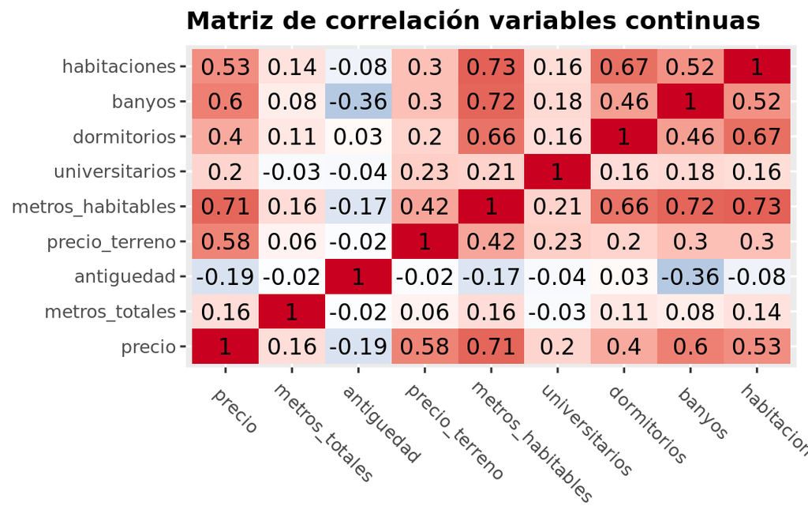

```r
plot_correlation(
  data = datos,
  type = "continuous",
  title = "Matriz de correlación variables continuas",
  theme_config = list(legend.position = "none",
                      plot.title = element_text(size = 12, face = "bold"),
                      axis.title = element_blank(),
                      axis.text.x = element_text(angle = -45, hjust = +0.1)
                     )
)
```

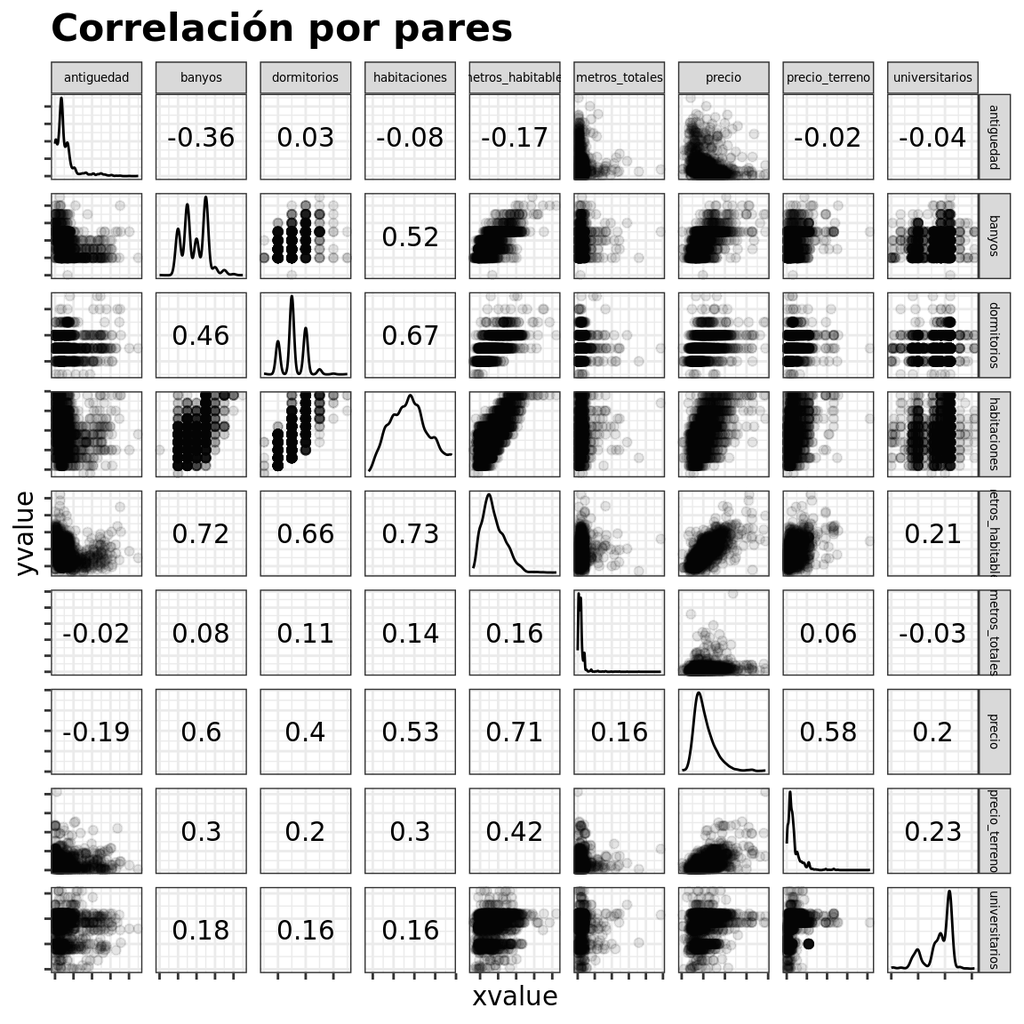

```r
GGally::ggscatmat(
  data = datos %>% select_if(is.numeric),
  alpha = 0.1) +
theme_bw() +
labs(title = "Correlación por pares") +
theme(
  plot.title = element_text(size = 16, face = "bold"),
  axis.text = element_blank(),
  strip.text = element_text(colour = "black", size = 5, face = 1)
)
```

## Variables cualitativas

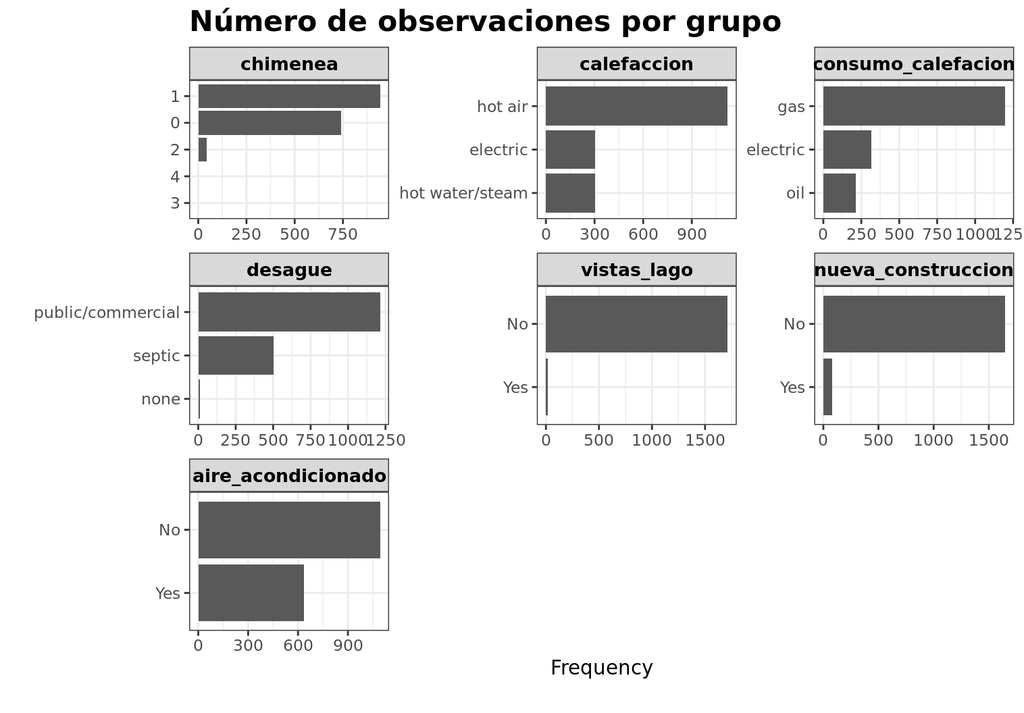

```r
plot_bar(
  datos,
  ncol    = 3,
  title   = "Número de observaciones por grupo",
  ggtheme = theme_bw(),
  theme_config = list(
                   plot.title = element_text(size = 16, face = "bold"),
                   strip.text = element_text(colour = "black", size = 10, face = 2),
                   legend.position = "none"
                  )
)
```

Si alguno de los niveles de una variable cualitativa tiene muy pocas observaciones en comparación a los otros niveles, puede ocurrir que, durante la validación cruzada o *bootstrapping*, algunas particiones no contengan ninguna observación de dicha clase (varianza cero), lo que puede dar lugar a errores. En estos casos, suele ser conveniente:

- Eliminar las observaciones del grupo minoritario si es una variable multiclase.
- Eliminar la variable si solo tiene dos niveles.
- Agrupar los niveles minoritarios en un único grupo.
- Asegurar que, en la creación de las particiones, todos los grupos estén representados en cada una de ellas.

Para este caso, hay que tener precaución con la variable `chimenea`. Se unifican los niveles de 2, 3 y 4 en un nuevo nivel llamado “2_mas”.

```r
table(datos$chimenea)
```

```
##
##   0   1   2   3   4
## 740 942  42   2   2
```

```r
datos <- datos %>%
         mutate(
           chimenea = recode_factor(
                        chimenea,
                        `2` = "2_mas",
                        `3` = "2_mas",
                        `4` = "2_mas"
                      )
         )

table(datos$chimenea)
```

```
##
## 2_mas     0     1
##    46   740   942
```

```r
custom_box_plot <- function(variable1, variable2, df, alpha=0.3){
  p <- df %>%
       mutate(
         # Truco para que se ponga el título estilo facet
        title = paste(toupper(variable2), "vs", toupper(variable1))
       ) %>%
       ggplot(aes(x = !!sym(variable1), y = !!sym(variable2))) +
       geom_violin(alpha = alpha) +
       geom_boxplot(width = 0.1, outlier.shape = NA) +
       facet_grid(. ~ title) +
       theme_bw() +
       theme(strip.text = element_text(colour = "black", size = 8, face = 2),
             axis.text.x = element_text(size = 7),
             axis.title = element_blank())
  return(p)
}
```

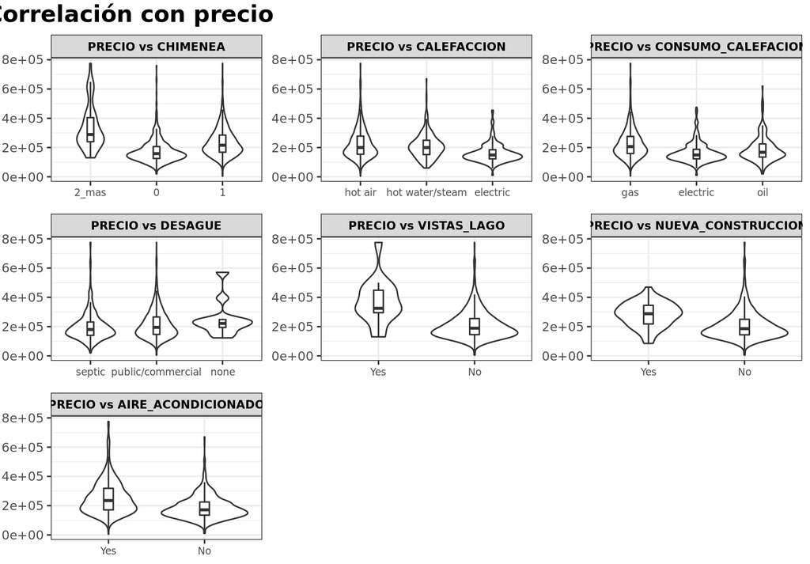

```r
variables_cualitativas <- c("chimenea", "calefaccion", "consumo_calefacion", "desague",
                            "vistas_lago", "nueva_construccion", "aire_acondicionado")

plots <- map(
            .x = variables_cualitativas,
            .f = custom_box_plot,
            variable2 = "precio",
            df = datos
         )

ggarrange(plotlist = plots, ncol = 3, nrow = 3) %>%
  annotate_figure(
    top = text_grob("Correlación con precio", face = "bold", size = 16,
                    x = 0.16)
  )
```

# Crear un modelo con **mlr3**

Encontrar el mejor modelo de *machine learning* capaz de representar los patrones presentes en los datos de entrenamiento y generalizarlos a nuevas observaciones no es fácil, existen multitud de algoritmos, cada uno con unas características propias y con distintos parámetros que deben ser ajustados. Por lo general, las etapas seguidas para obtener un buen modelo son:

- **Ajuste/entrenamiento**: consiste en aplicar un algoritmo de *machine learning* a los datos de entrenamiento para que el modelo aprenda.
- **Evaluación/validación**: el objetivo de un modelo predictivo no es ser capaz de predecir observaciones que ya se conocen, sino nuevas observaciones que el modelo no ha visto. Para poder estimar el error que comete un modelo es necesario recurrir a estrategias de validación entre las que destacan: validación simple, *bootstrap* y validación cruzada. $^{\text{Anexo 1}}$
- **Optimización de hiperparámetros**: muchos algoritmos de *machine learning* contienen en sus ecuaciones uno o varios parámetros que no se aprenden con los datos, a estos se les conoce como hiperparámetros. Por ejemplo, los [SVM lineal](https://www.cienciadedatos.net/documentos/34_maquinas_de_vector_soporte_support_vector_machines) tiene el hiperparámetro de coste *C* y los [árboles de regresión](https://www.cienciadedatos.net/documentos/33_arboles_de_prediccion_bagging_random_forest_boosting) la profundidad del árbol *tree_depth* y el número mínimo de observaciones por nodo *min_n*. No existe forma de conocer de antemano cuál es el valor exacto de un hiperparámetro que da lugar al mejor modelo, por lo que se tiene que recurrir a estrategias de validación para comparar distintos valores.
- **Predicción**: una vez creado el modelo, este se emplea para predecir nuevas observaciones.

Es a lo largo de todo este proceso donde más destacan las funcionalidades ofrecidas por **mlr3**, permitiendo emplear la misma sintaxis para ajustar, optimizar, evaluar y predecir un amplio abanico de modelos variando únicamente el nombre del algoritmo. Aunque **mlr3** permite todo esto con apenas unas pocas líneas de código, son muchos los argumentos que pueden ser adaptados, cada uno con múltiples posibilidades. Con el objetivo de exponer mejor cada una de las opciones, en lugar de crear directamente un modelo final, se muestran ejemplos de menor a mayor complejidad.

**Filosofía mlr3**

Los desarrolladores de **mlr3** han dividido las etapas de la creación de un modelo de *machine learning* en 6 “bloques” (Figura 1). Dentro cada uno de estos “bloques” se llevan a cabo una o varias acciones (preprocesado, *resampling*, entrenamiento, evaluación, predicción, etc). Al trabajar de esta forma, se consigue que cada “bloque” transmita al siguiente, no solo los datos, sino también toda la información de lo ha ocurrido hasta el momento.

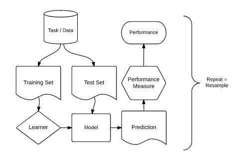

La secuencia de pasos con los que se crea un modelo predictivo en **mlr3** puede parecer extraña para aquellos lectores que estén acostumbrados a otras librerías como **caret**, en las que cada etapa es relativamente independiente del resto. En **mlr3**, sin embargo, primero se crean los objetos en los que se definen cada una las acciones para finalmente ejecutarlas de forma conjunta e interconectada.

El siguiente, es un listado ordenado que resume los pasos que hay que seguir para crear un modelo predictivo con **mlr3**.

1. Crear un `task`: el objeto `task` encapsula los datos, información sobre el tipo de variables, número de observaciones, el tipo de modelo (regresión, clasificación…) e identifica el rol de cada variable (predictores, respuesta, estratificación, pesos…). Los tipos de *task* disponibles son:
   - `mlr3::TaskReg`: modelos de regresión.
   - `mlr3::TaskClassif`: modelos de clasificación binaria o multiclase.
   - `mlr3::TaskSurv`: modelos de supervivencia.
   - `mlr3ordinal::TaskOrdinal`: modelos para datos ordinales.
   - Los `task` de *clustering* y *spatial* están pendientes de implementar.
2. Crear un `learner`: el objeto `learner` define qué algoritmo de aprendizaje se va a emplear, sus hiperparámetros y el tipo de predicción. Además, es en este objeto donde se especifica el preprocesado de datos.
3. Crear un `resample` y `measure`: el objeto `resample` define la estrategia de validación del modelo y el `measure` la métrica con la que se cuantifica su capacidad predictiva.
4. Entrenar el modelo: aplicando la función `train()` o `resample()` a un objeto `task`, un objeto `learner` y opcionalmente un objeto `resample`, se entrena el modelo y se estima su error.
5. Emplear el método `$predict()` del modelo entrenado para predecir nuevas observaciones.

## Task

El objeto `task` encapsula los datos, información sobre el tipo de variables, número de observaciones, el tipo de modelo (regresión, clasificación…) e identifica el rol de cada variable (predictores, respuesta, estratificación, la clase positiva para calcular métricas de clasificación binaria, pesos…).

```r
task_datos <- TaskRegr$new(
                id      = "task_datos",
                backend = datos,
                target  = "precio"
              )
task_datos
```

```
## <TaskRegr:task_datos> (1728 x 16)
## * Target: precio
## * Properties: -
## * Features (15):
##   - fct (7): aire_acondicionado, calefaccion, chimenea,
##     consumo_calefacion, desague, nueva_construccion, vistas_lago
##   - int (6): antiguedad, dormitorios, habitaciones, metros_habitables,
##     precio_terreno, universitarios
##   - dbl (2): banyos, metros_totales
```

**mlr3** incorpora toda una serie de atributos y métodos con los que extraer o modificar información de un objeto `task`: `$col_info`, `$col_roles`, `$missings()`, `$levels()`, `$select()`, `filter$()`. **Es importante tener en cuenta que, `$select()` y `filter$()`, modifican el objeto `task`.**

```r
# Información de todas las variables.
task_datos$col_info
```

| id | type | levels |
| --- | --- | --- |
| ..row_id | integer |  |
| aire_acondicionado | factor |  |
| antiguedad | integer |  |
| banyos | numeric |  |
| calefaccion | factor |  |
| chimenea | factor |  |
| consumo_calefacion | factor |  |
| desague | factor |  |
| dormitorios | integer |  |
| habitaciones | integer |  |

[output cut: 7 more lines]

```r
# Role de todas las variables.
task_datos$col_roles
```

```
## $feature
##  [1] "aire_acondicionado" "antiguedad"         "banyos"
##  [4] "calefaccion"        "chimenea"           "consumo_calefacion"
##  [7] "desague"            "dormitorios"        "habitaciones"
## [10] "metros_habitables"  "metros_totales"     "nueva_construccion"
## [13] "precio_terreno"     "universitarios"     "vistas_lago"
##
## $target
## [1] "precio"
##
## $name
## character(0)
##
## $order
## character(0)
##
## $stratum
## character(0)
##
## $group
## character(0)
##
## $weight
## character(0)
```

```r
# Número de valores NA por variable.
task_datos$missings()
```

```
##             precio aire_acondicionado         antiguedad             banyos
##                  0                  0                  0                  0
##        calefaccion           chimenea consumo_calefacion            desague
##                  0                  0                  0                  0
##        dormitorios       habitaciones  metros_habitables     metros_totales
##                  0                  0                  0                  0
## nueva_construccion     precio_terreno     universitarios        vistas_lago
##                  0                  0                  0                  0
```

```r
# Niveles de cada variable de tipo factor.
task_datos$levels()
```

```
## $aire_acondicionado
## [1] "Yes" "No"
##
## $calefaccion
## [1] "hot air"         "hot water/steam" "electric"
##
## $chimenea
## [1] "2_mas" "0"     "1"
##
## $consumo_calefacion
## [1] "gas"      "electric" "oil"
##
## $desague
## [1] "septic"            "public/commercial" "none"
##
## $nueva_construccion
## [1] "Yes" "No"
##
## $vistas_lago
## [1] "Yes" "No"
```

```r
# Mostrar datos por número de fila
task_datos$data(rows = 1:3)
```

| precio | aire_acondicionado | antiguedad | banyos | calefaccion | chimenea | consumo_calefacion | desague | dormitorios | habitaciones | metros_habitables | metros_totales | nueva_construccion | precio_terreno | universitarios | vistas_lago |
| --- | --- | --- | --- | --- | --- | --- | --- | --- | --- | --- | --- | --- | --- | --- | --- |
| 132500 | No | 42 | 1.0 | electric | 1 | electric | septic | 2 | 5 | 906 | 0.09 | No | 50000 | 35 | No |
| 181115 | No | 0 | 2.5 | hot water/steam | 0 | gas | septic | 3 | 6 | 1953 | 0.92 | No | 22300 | 51 | No |
| 109000 | No | 133 | 1.0 | hot water/steam | 1 | gas | public/commercial | 4 | 8 | 1944 | 0.19 | No | 7300 | 51 | No |

## División train-test

Evaluar la capacidad predictiva de un modelo consiste en comprobar cómo de próximas son sus predicciones a los verdaderos valores de la variable respuesta. Para poder cuantificarlo de forma correcta, se necesita disponer de un conjunto de observaciones, de las que se conozca la variable respuesta, pero que el modelo no haya “visto”, es decir, que no hayan participado en su ajuste. Con esta finalidad, se dividen los datos disponibles en un conjunto de entrenamiento y un conjunto de test. El tamaño adecuado de las particiones depende en gran medida de la cantidad de datos disponibles y la seguridad que se necesite en la estimación del error, 80%-20% suele dar buenos resultados. El reparto debe hacerse de forma aleatoria o aleatoria-estratificada. [Evaluación de modelos](https://www.cienciadedatos.net/documentos/30_cross-validation_oneleaveout_bootstrap).

El paquete **mlr3** dispone del objeto `resampling = rsmp("holdout")` para repartir en dos partes (*train-test*) los datos contenidos en un `task`. Con `$train_set()` y `$test_set()` se accede a los índices de las observaciones que caen en cada parte.

```r
set.seed(1234)
rsmp_holdout <- rsmp("holdout", ratio = 0.8)
rsmp_holdout
```

```
## <ResamplingHoldout> with 1 iterations
## * Instantiated: FALSE
## * Parameters: ratio=0.8
```

```r
# Para que el reparto sea estratificado, es necesario indicar en el task qué
# columna o columnas se emplea como stratum. Solo para variables cualitativas.
# task_datos$col_roles$stratum <- "precio"

rsmp_holdout$instantiate(task = task_datos)

# Índices train
id_train <- rsmp_holdout$train_set(i = 1)
# Índices test
id_test <- rsmp_holdout$test_set(i = 1)

# Se crean dos nuevas task, una con los datos de train y otra con los de test.
# Dado que se va a aplicar un filtrado, y para no alterar task_datos, se emplea
# antes del filtro el método $clone() para hacer una copia.
task_train <- task_datos$clone()$filter(id_train)
task_test  <- task_datos$clone()$filter(id_test)
```

Es importante verificar que la distribución de la variable respuesta es similar en el conjunto de entrenamiento y en el de test.

```r
summary(task_train$data()[["precio"]])
```

```
##    Min. 1st Qu.  Median    Mean 3rd Qu.    Max.
##   10300  145000  189000  211594  256838  775000
```

```r
summary(task_test$data()[["precio"]])
```

```
##    Min. 1st Qu.  Median    Mean 3rd Qu.    Max.
##    5000  142250  194000  213455  260000  760000
```

Cuando se emplea un `resampling`, si existe una o varias columnas con el role `stratum`, se realiza un reparto estratificado, garantizando así una distribución aproximada (por el momento, esto solo es válido para variables cualitativas). El reparto estratificado es muy importante cuando hay grupos minoritarios en alguna variable. Por ejemplo, en un set de datos con 100 observaciones, un predictor binario que tenga 90 observaciones de un grupo y solo 10 de otro, tiene un alto riesgo de que, en alguna de las particiones, el grupo minoritario no tenga representantes. Si esto ocurre en el conjunto de entrenamiento, algunos algoritmos darán error al aplicarlos al conjunto de test, ya que no entenderán el valor que se les está pasando. Este problema puede evitarse eliminando variables con varianza próxima a cero (ver más adelante).

## Preprocesado-mlr3pipelines

El preprocesado engloba todas aquellas transformaciones realizadas sobre los datos con el objetivo que puedan ser interpretados por el algoritmo de *machine learning* lo más eficientemente posible. Todo preprocesado de datos debe aprenderse con las observaciones de entrenamiento y luego aplicarse al conjunto de entrenamiento y al de test. Esto es muy importante para no violar la condición de que ninguna información procedente de las observaciones de test participe o influya en el ajuste del modelo. Este principio debe aplicarse también si se emplea validación cruzada (ver más adelante). En tal caso, el preporcesado debe realizarse dentro de cada iteración de validación, para que las estimaciones que se hacen con cada partición de validación no contengan información del resto de particiones. A continuación, se resumen algunos de los pasos de preprocesado que más se suelen necesitar.

**Imputación de valores ausentes**

La gran mayoría de algoritmos no aceptan observaciones incompletas, por lo que, cuando el set de datos contiene valores ausentes, se puede:

- Eliminar aquellas observaciones que estén incompletas.
- Eliminar aquellas variables que contengan valores ausentes.
- Tratar de estimar los valores ausentes empleando el resto de información disponible (imputación).

Las primeras dos opciones, aunque sencillas, suponen perder información. La eliminación de observaciones solo puede aplicarse cuando se dispone de muchas y el porcentaje de registros incompletos es muy bajo. En el caso de eliminar variables, el impacto dependerá de cuánta información aporten dichas variables al modelo. Cuando se emplea imputación, es muy importante tener en cuenta el riesgo que se corre al introducir valores en predictores que tengan mucha influencia en el modelo. Supóngase un estudio médico en el que, cuando uno de los predictores es positivo, el modelo predice casi siempre que el paciente está sano. Para un paciente cuyo valor de este predictor se desconoce, el riesgo de que la imputación sea errónea es muy alto, por lo que es preferible obtener una predicción basada únicamente en la información disponible. Esta es otra muestra de la importancia que tiene que el analista conozca el problema al que se enfrenta y pueda así tomar la mejor decisión.

**Exclusión de variables con varianza próxima a cero**

No se deben incluir en el modelo predictores que contengan un único valor (cero-varianza) ya que no aportan información. Tampoco es conveniente incluir predictores que tengan una varianza próxima a cero, es decir, predictores que toman solo unos pocos valores, de los cuales, algunos aparecen con muy poca frecuencia. El problema con estos últimos es que pueden convertirse en predictores con varianza cero cuando se dividen las observaciones por validación cruzada o *bootstrap*.

Si bien la eliminación de predictores no informativos podría considerarse un paso propio del proceso de *selección de predictores*, dado que consiste en un filtrado por varianza, tiene que realizarse antes de estandarizar los datos, ya que después, todos los predictores tienen varianza 1.

**Estandarización y escalado de variables numéricas**

Cuando los predictores son numéricos, la escala en la que se miden, así como la magnitud de su varianza pueden influir en gran medida en el modelo. Muchos algoritmos de *machine learning* (*SVM*, redes neuronales, *lasso…*) son sensibles a esto, de forma que, si no se igualan de alguna forma los predictores, aquellos que se midan en una escala mayor o que tengan más varianza dominarán el modelo aunque no sean los que más relación tienen con la variable respuesta. Existen principalmente 2 estrategias para evitarlo:

- **Centrado**: consiste en restarle a cada valor la media del predictor al que pertenece. Si los datos están almacenados en un *dataframe*, el centrado se consigue restándole a cada valor la media de la columna en la que se encuentra. Como resultado de esta transformación, todos los predictores pasan a tener una media de cero, es decir, los valores se centran en torno al origen.
- **Normalización (estandarización)**: consiste en transformar los datos de forma que todos los predictores estén aproximadamente en la misma escala. Hay dos formas de lograrlo:
  - Normalización Z-score: dividir cada predictor entre su desviación típica después de haber sido centrado, de esta forma, los datos pasan a tener una distribución normal.
    $$z = \frac{x - \mu}{\sigma}$$
  - Estandarización max-min: transformar los datos de forma que estén dentro del rango [0, 1].
    $$X_{norm} = \frac{X - X_{min}}{X_{max}-X_{min}}$$

Nunca se debe estandarizar las variables después de ser binarizadas (ver a continuación).

**Binarización de las variables cualitativas**

La binarización consiste en crear nuevas variables *dummy* con cada uno de los niveles de las variables cualitativas. A este proceso también se le conoce como *one hot encoding*. Por ejemplo, una variable llamada *color* que contenga los niveles *rojo*, *verde* y *azul*, se convertirá en tres nuevas variables (*color_rojo*, *color_verde*, *color_azul*), todas con el valor 0 excepto la que coincide con la observación, que toma el valor 1. Muchos modelos de *machine learning* y aprendizaje estadístico no pueden interpretar variables de tipo `character` o `factor`, por lo que es necesario hacer esta transformación.

La forma de preprocesar los datos dentro del ecosistema **mlr3** es mediante los paquetes `mlr3pipelines` y `mlrfilters`. Estos paquetes permite encadenar operadores `PipeOp` y `Filters`, cada uno aplica una transformación concreta, y ejecutarlos todos de forma secuencial. Una vez que han sido definidos, pueden ser entrenados con `$train()` para aprender las tranformaciones y luego aplicados a nuevos conjuntos de datos con `$pred()`. Son muchos los operadores disponibles y se continúan añadiendo más.

```r
# Operadores PipeOp disponibles
mlr_pipeops$keys()
```

```
##  [1] "boxcox"                "branch"                "chunk"
##  [4] "classbalancing"        "classifavg"            "classweights"
##  [7] "colapply"              "collapsefactors"       "colroles"
## [10] "copy"                  "datefeatures"          "encode"
## [13] "encodeimpact"          "encodelmer"            "featureunion"
## [16] "filter"                "fixfactors"            "histbin"
## [19] "ica"                   "imputeconstant"        "imputehist"
## [22] "imputelearner"         "imputemean"            "imputemedian"
## [25] "imputemode"            "imputeoor"             "imputesample"
## [28] "kernelpca"             "learner"               "learner_cv"
## [31] "missind"               "modelmatrix"           "multiplicityexply"
## [34] "multiplicityimply"     "mutate"                "nmf"
## [37] "nop"                   "ovrsplit"              "ovrunite"
## [40] "pca"                   "proxy"                 "quantilebin"
## [43] "randomprojection"      "randomresponse"        "regravg"
## [46] "removeconstants"       "renamecolumns"         "replicate"
## [49] "scale"                 "scalemaxabs"           "scalerange"
## [52] "select"                "smote"                 "spatialsign"
## [55] "subsample"             "targetinvert"          "targetmutate"
## [58] "targettrafoscalerange" "textvectorizer"        "threshold"
## [61] "tunethreshold"         "unbranch"              "vtreat"
## [64] "yeojohnson"
```

```r
# Filtros disponibles
mlr_filters$keys()
```

```
##  [1] "anova"            "auc"              "carscore"         "cmim"
##  [5] "correlation"      "disr"             "find_correlation" "importance"
##  [9] "information_gain" "jmi"              "jmim"             "kruskal_test"
## [13] "mim"              "mrmr"             "njmim"            "performance"
## [17] "permutation"      "variance"
```

Para este ejemplo se normalizan los datos y se hace una codificación *one-hot* de las variables cualitativas.

```r
preproces_pipeline <- po("scale", param_vals = list(center = TRUE, scale = TRUE)) %>>%
                      po("encode",param_vals = list(method = "one-hot"))

preproces_pipeline$train(task_train)
```

```
## $encode.output
## <TaskRegr:task_datos> (1382 x 27)
## * Target: precio
## * Properties: -
## * Features (26):
##   - dbl (26): aire_acondicionado.No, aire_acondicionado.Yes,
##     antiguedad, banyos, calefaccion.electric, calefaccion.hot.air,
##     calefaccion.hot.water.steam, chimenea.0, chimenea.1,
##     chimenea.2_mas, consumo_calefacion.electric,
##     consumo_calefacion.gas, consumo_calefacion.oil, desague.none,
##     desague.public.commercial, desague.septic, dormitorios,
##     habitaciones, metros_habitables, metros_totales,
##     nueva_construccion.No, nueva_construccion.Yes, precio_terreno,
##     universitarios, vistas_lago.No, vistas_lago.Yes
```

Los resultados (`output`) de un operador `mlr3pipelines` siempre son una lista, en la que el primer elemento (`[[1]]`) contiene los datos transformados.

```r
task_train_prerp <- preproces_pipeline$predict(task_train)[[1]]$clone()
task_test_prerp  <- preproces_pipeline$predict(task_test)[[1]]$clone()
task_train_prerp$data() %>% head()
```

| precio | antiguedad | banyos | dormitorios | habitaciones | metros_habitables | metros_totales | precio_terreno | universitarios | aire_acondicionado.Yes | aire_acondicionado.No | calefaccion.hot.air | calefaccion.hot.water.steam | calefaccion.electric | chimenea.2_mas | chimenea.0 | chimenea.1 | consumo_calefacion.gas | consumo_calefacion.electric | consumo_calefacion.oil | desague.septic | desague.public.commercial | desague.none | nueva_construccion.Yes | nueva_construccion.No | vistas_lago.Yes | vistas_lago.No |
| --- | --- | --- | --- | --- | --- | --- | --- | --- | --- | --- | --- | --- | --- | --- | --- | --- | --- | --- | --- | --- | --- | --- | --- | --- | --- | --- |
| 155000 | -0.5071811 | -0.6008474 | -0.1813205 | -0.8864042 | 0.3097915 | -0.1197117 | -0.4442896 | -0.449278 | 0 | 1 | 1 | 0 | 0 | 0 | 0 | 1 | 1 | 0 | 0 | 1 | 0 | 0 | 0 | 1 | 0 | 1 |
| 86060 | -0.9549900 | -1.3564172 | -1.3977520 | -1.7536684 | -1.4777477 | -0.5374231 | -0.5459665 | -0.449278 | 1 | 0 | 1 | 0 | 0 | 0 | 1 | 0 | 1 | 0 | 0 | 0 | 1 | 0 | 1 | 0 | 0 | 1 |
| 120000 | 0.1128620 | -1.3564172 | 1.0351110 | 0.4144920 | -0.9725736 | 0.2562286 | -0.5734467 | -3.273331 | 0 | 1 | 1 | 0 | 0 | 0 | 0 | 1 | 1 | 0 | 0 | 1 | 0 | 0 | 0 | 1 | 0 | 1 |
| 170000 | -0.1627127 | -0.6008474 | 1.0351110 | 0.8481241 | -0.1468082 | 0.9941855 | -0.5569586 | -2.007376 | 0 | 1 | 1 | 0 | 0 | 0 | 0 | 1 | 0 | 0 | 1 | 1 | 0 | 0 | 0 | 1 | 0 | 1 |
| 90000 | 0.2850962 | -0.6008474 | -0.1813205 | 0.4144920 | -0.1953826 | 0.4650843 | -0.3481087 | -0.449278 | 0 | 1 | 0 | 0 | 1 | 0 | 1 | 0 | 0 | 1 | 0 | 1 | 0 | 0 | 0 | 1 | 0 | 1 |
| 122900 | -0.8172027 | -0.6008474 | -0.1813205 | -0.4527721 | -0.5451185 | 2.0106166 | -0.3755890 | -1.130946 | 0 | 1 | 1 | 0 | 0 | 0 | 1 | 0 | 1 | 0 | 0 | 0 | 0 | 1 | 0 | 1 | 0 | 1 |

## Modelo-Learner

El siguiente paso tras definir los datos de entrenamiento, es seleccionar el algoritmo que se va a emplear. En **mlr3**, esto se hace mediante la creación de un objeto `learner`. En concreto, este objeto almacena el nombre del algoritmo, sus parámetros e hiperparámetros y el tipo de resultado que se muestra al predecir nuevas observaciones. El paquete `mlr3learners` contiene solo los principales algoritmos empleados para clasificación y regresión ([listado](https://mlr3learners.mlr-org.com/)).

```r
# Listado de learners disponibles en mlr3learners
mlr_learners$keys()
```

```
##  [1] "classif.cv_glmnet"   "classif.debug"       "classif.featureless"
##  [4] "classif.glmnet"      "classif.kknn"        "classif.lda"
##  [7] "classif.log_reg"     "classif.multinom"    "classif.naive_bayes"
## [10] "classif.qda"         "classif.ranger"      "classif.rpart"
## [13] "classif.svm"         "classif.xgboost"     "regr.cv_glmnet"
## [16] "regr.featureless"    "regr.glmnet"         "regr.kknn"
## [19] "regr.km"             "regr.lm"             "regr.ranger"
## [22] "regr.rpart"          "regr.svm"            "regr.xgboost"
## [25] "surv.cv_glmnet"      "surv.glmnet"         "surv.ranger"
## [28] "surv.xgboost"
```

Pero existen toda una serie de extensiones con otros algoritmos ([listado](https://mlr3learners.mlr-org.com/dev/articles/additional-learners.html)). Por ejemplo, los modelos *SVM* del paquete `kernlab`.

```r
#install.packages("mlr3learners.kernlab")
# Si no funciona probar:
#install.packages("remotes")
#remotes::install_github("mlr3learners/mlr3learners.kernlab")
library(mlr3learners.kernlab)
mlr_learners$keys()
```

```
##  [1] "classif.cv_glmnet"   "classif.debug"       "classif.featureless"
##  [4] "classif.glmnet"      "classif.kknn"        "classif.ksvm"
##  [7] "classif.lda"         "classif.log_reg"     "classif.multinom"
## [10] "classif.naive_bayes" "classif.qda"         "classif.ranger"
## [13] "classif.rpart"       "classif.svm"         "classif.xgboost"
## [16] "regr.cv_glmnet"      "regr.featureless"    "regr.glmnet"
## [19] "regr.kknn"           "regr.km"             "regr.ksvm"
## [22] "regr.lm"             "regr.ranger"         "regr.rpart"
## [25] "regr.svm"            "regr.xgboost"        "surv.cv_glmnet"
## [28] "surv.glmnet"         "surv.ranger"         "surv.xgboost"
```

Para crear un nuevo `learner` se puede emplear a la función `lrn()` o al método `mlr_learners$get()`.

```r
# Se crea un learner con el algoritmo de SVM
learner_svm <- lrn("regr.svm")
# learner_svm <- mlr_learners$get(key = "regr.svm")
```

Imprimiendo el `learner` se muestra información general sobre el algoritmo:

- `feature_types`: tipo de variables que el algoritmo es capaz de aceptar (importante para identificar aquellos que no pueden tratar con factores.
- `packages`: el paquete al que pertenece el algoritmo.
- `properties`: propiedades adicionales del algoritmo. Por ejemplo, “missings” significa que puede tratar con valores ausentes, y “importance” significa que el algoritmo es capaz de calcular la importancia de los predictores.
- `predict_types`: tipo de predicción.
  - Clasificación: “response” devuelve únicamente la clase con mayor probabilidad y “prob” devuelve además la probabilidad de cada clase.
  - Regresión: “response” devuelve el valor predicho y “se” devuelve además el error estándar de la predicción.
  - Supervivencia (Pendiente de implementar): “response” devuelve una medida de “risk” y “prob” devuelve la probabilidad en función del tiempo.
  - Clustering (Pendiente de implementar): “response” devuelve el id del *cluster* al que se ha asignado cada observación y “prob” devuelve la probabilidad de asignación a cada *cluster* (solo para *fuzzy clustering*).

```r
# Información general del learner
print(learner_svm)
```

```
## <LearnerRegrSVM:regr.svm>
## * Model: -
## * Parameters: list()
## * Packages: e1071
## * Predict Type: response
## * Feature types: logical, integer, numeric
## * Properties: -
```

Para conocer en detalle sus parámetros (hiperparámetros), el rango de valores válido y los valores por defecto, se emplea el atributo `$param_set`.

```r
# Tabla con toda la información
knitr::kable(as.data.table(learner_svm$param_set), format = "markdown")
```

| id | class | lower | upper | levels | nlevels | is_bounded | special_vals | default | storage_type | tags |
| --- | --- | --- | --- | --- | --- | --- | --- | --- | --- | --- |
| type | ParamFct | NA | NA | eps-regression, nu-regression | 2 | TRUE | NULL | eps-regression | character | train |
| kernel | ParamFct | NA | NA | linear , polynomial, radial , sigmoid | 4 | TRUE | NULL | radial | character | train |
| degree | ParamInt | 1 | Inf | NULL | Inf | FALSE | NULL | 3 | integer | train |
| coef0 | ParamDbl | -Inf | Inf | NULL | Inf | FALSE | NULL | 0 | numeric | train |
| cost | ParamDbl | 0 | Inf | NULL | Inf | FALSE | NULL | 1 | numeric | train |
| nu | ParamDbl | -Inf | Inf | NULL | Inf | FALSE | NULL | 0.5 | numeric | train |
| gamma | ParamDbl | 0 | Inf | NULL | Inf | FALSE | NULL | <environment: 0x562a4b469ce8> | numeric | train |
| cachesize | ParamDbl | -Inf | Inf | NULL | Inf | FALSE | NULL | 40 | numeric | train |
| tolerance | ParamDbl | 0 | Inf | NULL | Inf | FALSE | NULL | 0.001 | numeric | train |
| epsilon | ParamDbl | 0 | Inf | NULL | Inf | FALSE | NULL | <environment: 0x562a4b3adae0> | numeric | train |
| shrinking | ParamLgl | NA | NA | TRUE, FALSE | 2 | TRUE | NULL | TRUE | logical | train |
| cross | ParamInt | 0 | Inf | NULL | Inf | FALSE | NULL | 0 | integer | train |
| fitted | ParamLgl | NA | NA | TRUE, FALSE | 2 | TRUE | NULL | TRUE | logical | train |
| scale | ParamUty | NA | NA | NULL | Inf | FALSE | NULL | TRUE | list | train |

```r
# Valores de los parámetros cualitativos
learner_svm$param_set$levels %>% purrr::discard(is.null)
```

```
## $type
## [1] "eps-regression" "nu-regression"
##
## $kernel
## [1] "linear"     "polynomial" "radial"     "sigmoid"
##
## $shrinking
## [1]  TRUE FALSE
##
## $fitted
## [1]  TRUE FALSE
```

```r
# Valores por defecto
learner_svm$param_set$default %>% as.data.frame()
```

| type | kernel | degree | coef0 | cost | nu | cachesize | tolerance | shrinking | cross | fitted | scale |
| --- | --- | --- | --- | --- | --- | --- | --- | --- | --- | --- | --- |
| eps-regression | radial | 3 | 0 | 1 | 0.5 | 40 | 0.001 | TRUE | 0 | TRUE | TRUE |

Los parámetros (hiperparámetros) del `learner` pueden configurarse en el momento de su creación o modificarlos posteriormente.

```r
learner_svm <- lrn("regr.svm", type = "eps-regression", kernel = "linear", cost = 0.5)
learner_svm
```

```
## <LearnerRegrSVM:regr.svm>
## * Model: -
## * Parameters: type=eps-regression, kernel=linear, cost=0.5
## * Packages: e1071
## * Predict Type: response
## * Feature types: logical, integer, numeric
## * Properties: -
```

```r
learner_svm$param_set$values <- list(type = "eps-regression", kernel = "linear", cost = 0.5)
```

Además de los parámetros, otra característica importante que se puede modificar es `predict_type`, que determina tipo de resultado devuelto en las predicciones.

```r
learner_svm$predict_type <- "response"
```

## Entrenamiento

Una vez creado el `task` y el `learner`, se puede entrenar el modelo. Se procede a ajustar un modelo [máquinas vector soporte lineal (SVM)](https://www.cienciadedatos.net/documentos/34_maquinas_de_vector_soporte_support_vector_machines) que prediga el precio de la vivienda en función de todos los predictores. A excepción del tipo de SVM y de kernel, todos los demás parámetros se dejan por defecto.

```r
# Definición del learner
learner_svm <- lrn("regr.svm", type = "eps-regression", kernel = "linear")
```

El entrenamiento se realiza únicamente con las observaciones que forman parte de la partición de *train*, que están almacenadas en `task_train`.

```r
# Entrenamiento del learner
learner_svm$train(task = task_train_prerp)
```

El modelo generado se almacena en dentro del `learner` en el elemento `$model`. El modelo sigue manteniendo la misma clase que en el paquete original, por lo que puede manipularse acorde a todos sus métodos y funciones originales. Esto es importante a la hora de decidir qué hacer con el modelo final. Por ejemplo, si este modelo se quiere poner en producción, no sería necesario instalar todos los paquetes de **mlr3**, únicamente el paquete `e1071`,

```r
learner_svm$model
```

```
##
## Call:
## svm.default(x = data, y = task$truth(), type = "eps-regression",
##     kernel = "linear")
##
##
## Parameters:
##    SVM-Type:  eps-regression
##  SVM-Kernel:  linear
##        cost:  1
##       gamma:  0.03846154
##     epsilon:  0.1
##
##
## Number of Support Vectors:  1161
```

## Validación

La finalidad última de un modelo es predecir la variable respuesta en observaciones futuras o en observaciones que el modelo no ha “visto” antes. El error mostrado por defecto tras entrenar un modelo suele ser el error de entrenamiento, el error que comete el modelo al predecir las observaciones que ya ha “visto”. Si estos errores son útiles para entender cómo está aprendiendo el modelo (estudio de residuos), no es una estimación realista de cómo se comporta el modelo ante nuevas observaciones (el error de entrenamiento suele ser demasiado optimista). Para conseguir una estimación más certera, y antes de recurrir al conjunto de test, se pueden emplear estrategias de validación basadas en *resampling*. El paquete `mlr3` incorpora las siguientes estrategias: *Bootstrap* (`mlr_resamplings_bootstrap`), *V-Fold Cross-Validation* (`mlr_resamplings_cv`), *Repeated V-Fold Cross-Validation* (`mlr_resamplings_repeated_cv`) y *Monte Carlo Cross-Validation* (`mlr_resamplings_subsampling`) $^{\text{Anexo 1}}$. Cada uno funciona internamente de forma distinta, pero todos ellos se basan en la idea: ajustar y evaluar el modelo de forma repetida, empleando cada vez distintos subconjuntos creados a partir de los datos de entrenamiento y obteniendo en cada repetición una estimación del error. El promedio de todas las estimaciones tiende a converger en el valor real del error de test.

```r
# Métodos de resampling disponibles
as.data.table(mlr_resamplings)
```

| key | params | iters |
| --- | --- | --- |
| bootstrap |  | 30 |
| custom |  | 0 |
| cv |  | 10 |
| holdout |  | 1 |
| insample |  | 1 |
| loo |  | NA |
| repeated_cv |  | 100 |
| subsampling |  | 30 |

En primer lugar, se crea un objeto `Resampling` en el que se define el tipo de validación y el número de repeticiones.

```r
# Validación cruzada con 10 particiones
set.seed(123)
resampling_cv <- rsmp("cv", folds = 10)
resampling_cv
```

```
## <ResamplingCV> with 10 iterations
## * Instantiated: FALSE
## * Parameters: folds=10
```

Con la función `resample()` se combinan un `task`, un `learner` y la estrategia de `Resampling`. De esta forma el modelo se ajusta y evalúa con cada una de las particiones de forma automática, calculando y almacenando en cada iteración la métrica de interés.

```r
# Métricas disponibles
mlr_measures
```

```
## <DictionaryMeasure> with 54 stored values
## Keys: classif.acc, classif.auc, classif.bacc, classif.bbrier,
##   classif.ce, classif.costs, classif.dor, classif.fbeta, classif.fdr,
##   classif.fn, classif.fnr, classif.fomr, classif.fp, classif.fpr,
##   classif.logloss, classif.mbrier, classif.mcc, classif.npv,
##   classif.ppv, classif.prauc, classif.precision, classif.recall,
##   classif.sensitivity, classif.specificity, classif.tn, classif.tnr,
##   classif.tp, classif.tpr, debug, oob_error, regr.bias, regr.ktau,
##   regr.mae, regr.mape, regr.maxae, regr.medae, regr.medse, regr.mse,
##   regr.msle, regr.pbias, regr.rae, regr.rmse, regr.rmsle, regr.rrse,
##   regr.rse, regr.rsq, regr.sae, regr.smape, regr.srho, regr.sse,
##   selected_features, time_both, time_predict, time_train
```

```r
# Se define la métrica de evaluación
metrica <- msr("regr.rmse")

# Se aplica el resampling
resultados_resampling <- resample(
                           task         = task_train_prerp,
                           learner      = learner_svm,
                           resampling   = resampling_cv,
                           store_models = FALSE
                         )
```

[output not shown]

El objeto `ResampleResult` creado almacena toda la información sobre cada iteración.

```r
resultados_resampling
```

```
## <ResampleResult> of 10 iterations
## * Task: task_datos
## * Learner: regr.svm
## * Warnings: 0 in 0 iterations
## * Errors: 0 in 0 iterations
```

```r
# Métricas promedio de todas las particiones
resultados_resampling$aggregate(measures = msr("regr.rmse"))
```

```
## regr.rmse
##  58186.11
```

```r
# Métricas individuales de cada una de las particiones
resultados_resampling$score(msr("regr.rmse")) %>%
  as.data.table()
```

| task | task_id | learner | learner_id | resampling | resampling_id | iteration | prediction | regr.rmse |
| --- | --- | --- | --- | --- | --- | --- | --- | --- |
|  | task_datos |  | regr.svm |  | cv | 1 |  | 37622.38 |
|  | task_datos |  | regr.svm |  | cv | 2 |  | 65605.99 |
|  | task_datos |  | regr.svm |  | cv | 3 |  | 47629.88 |
|  | task_datos |  | regr.svm |  | cv | 4 |  | 54603.59 |
|  | task_datos |  | regr.svm |  | cv | 5 |  | 65695.03 |
|  | task_datos |  | regr.svm |  | cv | 6 |  | 83000.45 |
|  | task_datos |  | regr.svm |  | cv | 7 |  | 69663.36 |
|  | task_datos |  | regr.svm |  | cv | 8 |  | 51493.48 |
|  | task_datos |  | regr.svm |  | cv | 9 |  | 66185.10 |
|  | task_datos |  | regr.svm |  | cv | 10 |  | 40361.84 |

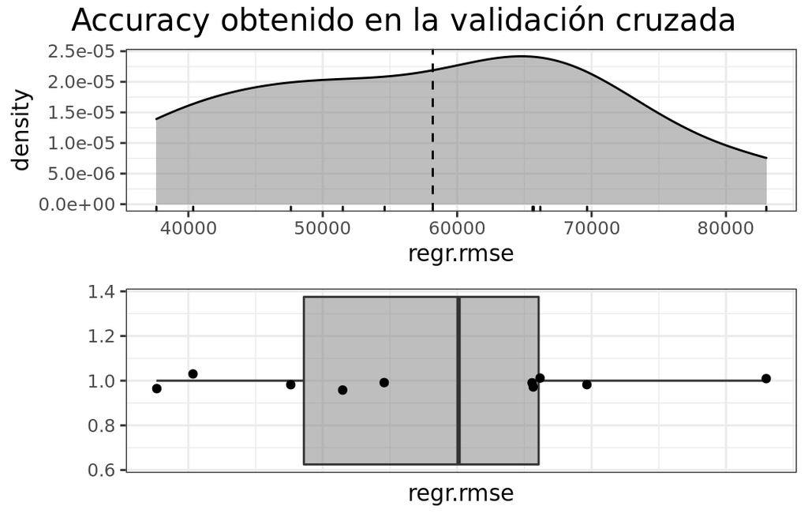

```r
# Distribución del error de validación
metricas <- resultados_resampling$score(msr("regr.rmse")) %>%
            as.data.table() %>%
            select(iteration, regr.rmse)

p1 <- ggplot(data = metricas, aes(x = regr.rmse)) +
      geom_density(alpha = 0.5, fill = "gray50") +
      geom_rug() +
      geom_vline(xintercept = mean(metricas$regr.rmse),
                 linetype = "dashed") +
      theme_bw()

p2 <- ggplot(data = metricas, aes(x = 1, y = regr.rmse)) +
      geom_boxplot(outlier.shape = NA, alpha = 0.5, fill = "gray50") +
      geom_jitter(width = 0.05) +
      coord_flip() +
      labs(x = "") +
      theme_bw() +
      theme(axis.text.x = element_blank(), axis.ticks.x = element_blank())

ggarrange(p1, p2, nrow = 2, align = "v") %>%
annotate_figure(
    top = text_grob("Accuracy obtenido en la validación cruzada",
                    size = 15)
)
```